# Univariate Survival Analysis

## Kaplan-Meier Plots

For your paper you will want to provide Kaplan-Meier plots of your results. The survminer package has revolutionized drawing of Kaplan-Meier plots in R. The survivalAnalysis package fully integrates plotting with survminer, providing sane defaults:

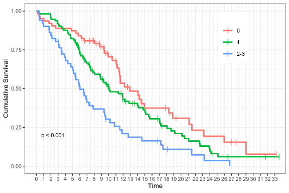

```r
kaplan_meier_plot(result)
```

Apparently, some details need tweaking. The relevant function, `ggsurvplot()`, is highly customizable, please refer to its documentation! All parameters supported by ggsurvplot can simply be passed to `kaplan_meier_plot()`. In addition, there are some shortcuts which we will now use.

We want to add * x axis label for OS * x axis breaks by quarter year * legend label * display the hazard ratios * a risk table, but “clean” only with minimal overhead * use a theme of our choice

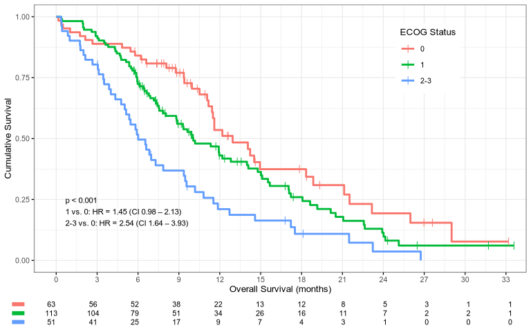

```r
kaplan_meier_plot(result,
                  break.time.by="breakByQuarterYear",
                  xlab=".OS.months",
                  legend.title="ECOG Status",
                  hazard.ratio=TRUE,
                  risk.table=TRUE,
                  table.layout="clean",
                  ggtheme=ggplot2::theme_bw(10))
```

What about differences by sex? Let’s draw two KM plots side-by-side using `kaplan_meier_grid()`. This piece of code also demonstrates the possible use of lists of default arguments, which can be overridden. If arguments differ per-plot, there is the mapped_plot_args argument.

Internally, `gridExtra::marrangeGrob()` does the layout. For some reason, the returned value needs an explicit `print()`. Normally you will want to save it to PDF. I recommend using `tidytidbits`’ `save_pdf`, into which you can simply pipe the kaplan_meier_grid output.

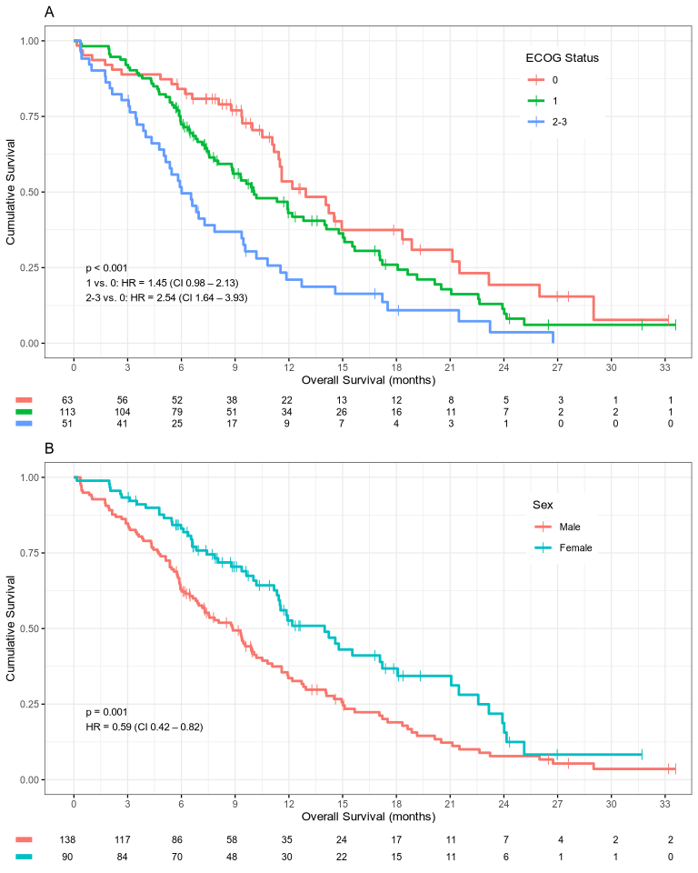

```r
default_args <- list(break.time.by="breakByMonth",
                     xlab=".OS.months",
                     legend.title="ECOG Status",
                     hazard.ratio=TRUE,
                     risk.table=TRUE,
                     table.layout="clean",
                     ggtheme=ggplot2::theme_bw(10))
list(result,
     survival::lung %>%
       analyse_survival(vars(time, status),
                        by=sex,
                        by_label_map=c(`1`="Male", `2`="Female"))
     ) %>%
  kaplan_meier_grid(nrow=2,
                    default_args,
                    break.time.by="breakByQuarterYear",
                    mapped_plot_args=list(
                      legend.title=c("ECOG Status", "Sex"),
                      title=c("A", "B")
                    )) %>%
  print
```